# Part II - Used Car Data Presentation

## by Betabasi Daniel

## Investigation Overview

> The overall goal of my presentation is to determine the variables that are significant in predicting the price of a used car and how well the variables describe the price of a car. Secondly, I intend to determine the car brands that are selling the most and the specific locations that are selling more.

> The brands of cars that sells more have these in common. They mostly have manual transmission type, use either diesel or petrol as their fuel type and are sold by individuals. Maruti is the most sold brand, followed by Hyundai, Mahindra, Tata and Toyota respectively while Daewoo is the brand with the least number of sales recorded.

> Among the four regions available, East has the most sales, followed by Central and West with South having the least sales but despite the number of sales made by the four regions, the average selling prices of cars seems to be higher in the South and Central regions over the years. This indicates that cars are more expensive in the two regions as compared to the other two regions, East and West.

## Dataset Overview

> Used Car Data is a large dataset of different types of used cars across the market gathered by a consulting firm based on various market surveys. It has 7906 entries of used cars having 18 features with data types of floats, integers and strings.

## (Visualization 1)

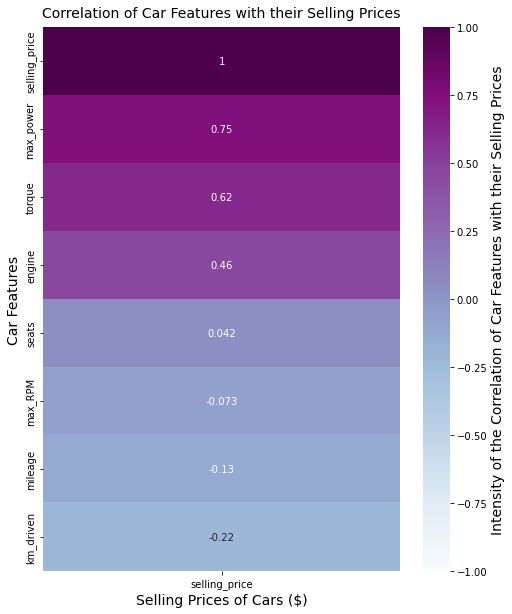

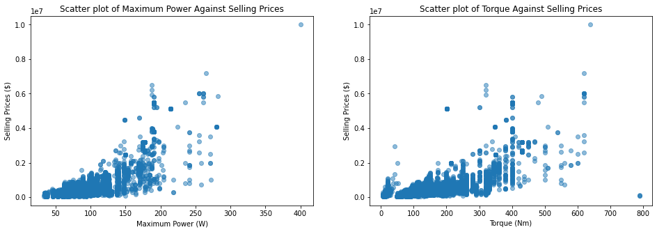

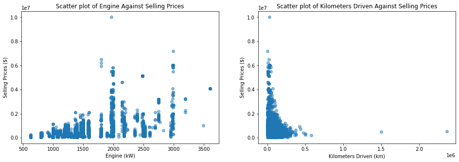

## (Visualization 2)

> The brands of cars that sells more have these in common. They mostly have manual transmission type, use either diesel or petrol as their fuel type and are sold by individuals. Maruti is the most sold brand, followed by Hyundai, Mahindra, Tata and Toyota respectively while Daewoo is the brand with the least number of sales recorded.

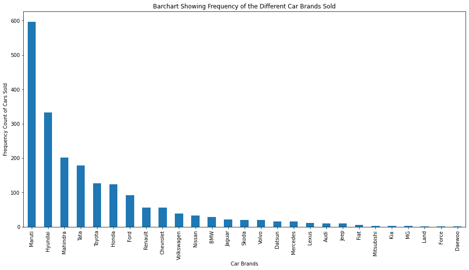

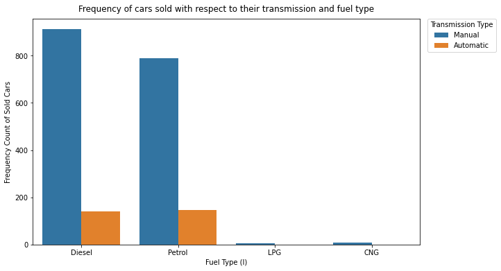

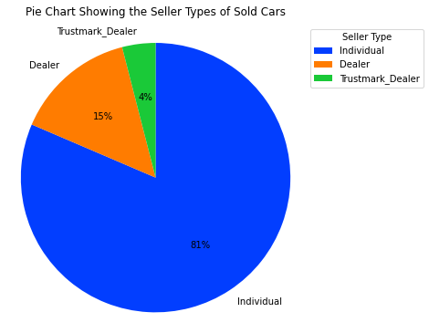

## (Visualization 3)

> Among the four regions available, East has the most sales, followed by Central and West with South having the least sales but despite the number of sales made by the four regions, the average selling prices of cars seems to be higher in the South and Central regions over the years. This indicates that cars are more expensive in the two regions as compared to the other two regions, East and West.

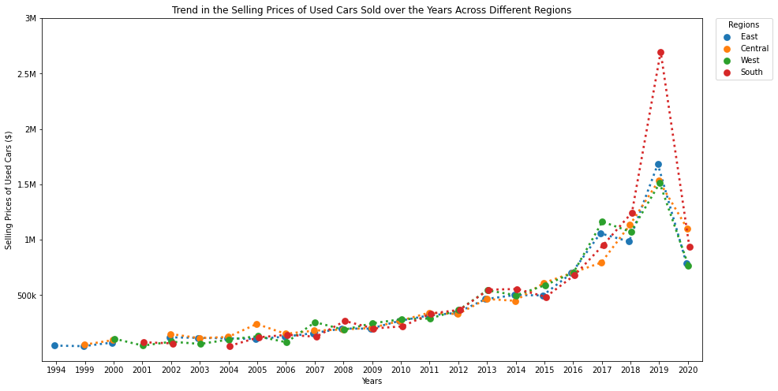

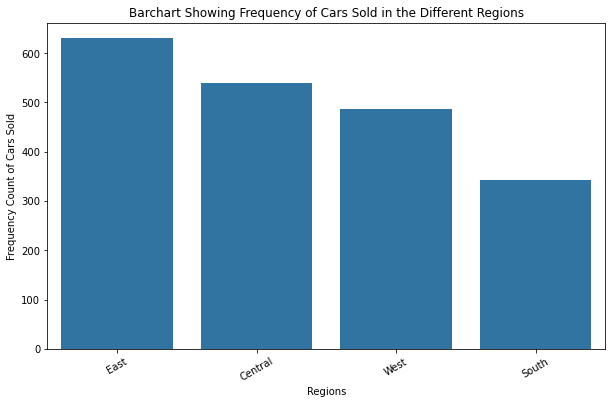